# EDA and ESDA

## EDA and ESDA

##### In-depth Articles

> EDA: Insieme di tecniche che mirano a produrre una prima rappresentazione del processo analizzato e valutare la coerenza degli assunti dell’Analysis che si vuole condurre con i dati osservati (Esempio: statistiche descrittive di sintesi, dati mancanti, presenza di valori anomali, gaussianità, etc.).

> ESDA: EDA di aspetti spaziali (Esempio: esplorazione delle condizioni di Stationarity locali o globali del processo studiato).

In questo articolo andremo ad analizzare le principali tecniche utilizzate nell’ambito dell’Analysis spaziale.

Per riuscire a comprendere meglio i vari argomenti faremo degli esempi pratici utilizzando un dataset volto a determinare la distribuzione e l’abbondanza delle capesante e della fauna associata delle capesante nella baia di New York.

https://catalog.data.gov/dataset/sea-scallop-survey

```r
setwd("Folder path")

myscallops <- read.table("scallops.txt", header=T)
```

## EDA (Exploratory Data Analysis)

#### Statistiche descrittive di sintesi

```r
dim(myscallops)       # numero di osservazioni e variabili
```

```
## [1] 148   7
```

```r
str(myscallops)       # descrizione sintetica dataset
```

```
## 'data.frame':    148 obs. of  7 variables:
##  $ strata  : int  6350 6350 6350 6350 6350 6350 6310 6310 6310 6310 ...
##  $ sample  : int  1 2 3 4 5 6 7 8 9 10 ...
##  $ lat     : num  40.5 40.5 40.5 40.4 40.3 ...
##  $ long    : num  -71.5 -71.5 -71.7 -71.8 -71.8 ...
##  $ tcatch  : int  0 0 0 1 0 0 2 0 7 13 ...
##  $ prerec  : int  0 0 0 0 0 0 1 0 3 6 ...
##  $ recruits: int  0 0 0 1 0 0 1 0 4 7 ...
```

```r
head(myscallops)       # prime righe del dataset
```

```
##   strata sample      lat      long tcatch prerec recruits
## 1   6350      1 40.55000 -71.55000      0      0        0
## 2   6350      2 40.46667 -71.51667      0      0        0
## 3   6350      3 40.51667 -71.71667      0      0        0
## 4   6350      4 40.38333 -71.85000      1      0        1
## 5   6350      5 40.31667 -71.78333      0      0        0
## 6   6350      6 40.26667 -71.88333      0      0        0
```

```r
summary(myscallops)    # descrizione dei dati
```

```
##      strata         sample           lat             long
##  Min.   :6220   Min.   :  1.0   Min.   :38.60   Min.   :-73.70
##  1st Qu.:6260   1st Qu.:106.8   1st Qu.:39.46   1st Qu.:-73.14
##  Median :6290   Median :147.0   Median :39.98   Median :-72.74
##  Mean   :6288   Mean   :131.8   Mean   :39.91   Mean   :-72.72
##  3rd Qu.:6310   3rd Qu.:185.2   3rd Qu.:40.41   3rd Qu.:-72.31
##  Max.   :6350   Max.   :224.0   Max.   :40.92   Max.   :-71.52
##      tcatch           prerec           recruits
##  Min.   :   0.0   Min.   :   0.00   Min.   :   0.00
##  1st Qu.:   8.0   1st Qu.:   1.00   1st Qu.:   5.00
##  Median :  30.0   Median :   8.00   Median :  21.50
##  Mean   : 274.6   Mean   : 156.55   Mean   : 118.06
##  3rd Qu.: 115.2   3rd Qu.:  48.25   3rd Qu.:  73.75
##  Max.   :7084.0   Max.   :4487.00   Max.   :2597.00
```

#### Grafici globali descrittivi

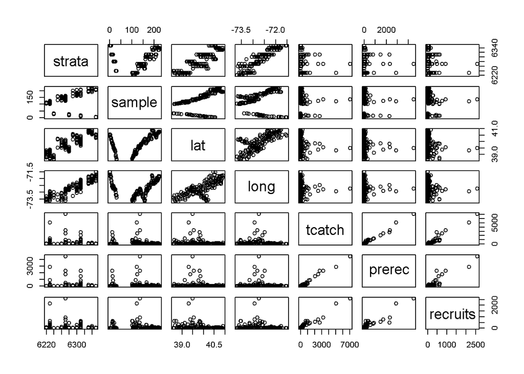

```r
pairs(myscallops)
```

#### Istogrammi per capire la distribuzione

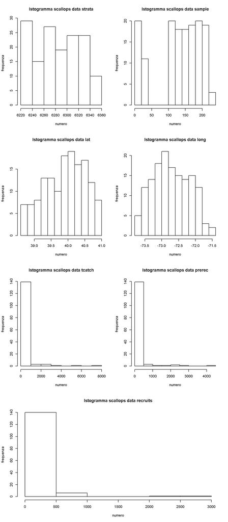

```r
if(ncol(myscallops)%%2==0){
  par(mfrow=c(2,ncol(myscallops)))
}
if(ncol(myscallops)%%3==0){
  par(mfrow=c(3,ncol(myscallops)))
}
layout(matrix(c(1:7,7), 4, 2, byrow = TRUE))
for(i in 1:ncol(myscallops)){
  hist(myscallops[,i],main=paste("Istogramma scallops data",colnames(myscallops)[i]),xlab="numero",ylab="frequenza")
}
```

```r
par(mfrow=c(1,1))
```

#### My function: Scatter con trend

[figure not shown]

```r
scattercontrend<-function(db,l,t,simbolo = 2){
  x<-as.numeric(as.vector(db[,l]))
  y<-as.numeric(as.vector(db[,t]))

  plot(x,y,pch=simbolo, xlab = colnames(db)[t],ylab = colnames(db)[l],main =paste("Scatter plot between",colnames(db)[l],"and",colnames(db)[t]) )
  lines(lowess(cbind(x,y), f = 1/3), col=4, lwd= 5)
};
#pch = 0,square
#pch = 1,circle
#pch = 2,triangle point up
#pch = 3,plus
#pch = 4,cross
#pch = 5,diamond
#pch = 6,triangle point down
#pch = 7,square cross
#pch = 8,star
#pch = 9,diamond plus
#pch = 10,circle plus
#pch = 11,triangles up and down
#pch = 12,square plus
#pch = 13,circle cross
#pch = 14,square and triangle down
#pch = 15, filled square
#pch = 16, filled circle
#pch = 17, filled triangle point-up
#pch = 18, filled diamond
#pch = 19, solid circle
#pch = 20,bullet (smaller circle)
#pch = 21, filled circle blue
#pch = 22, filled square blue
#pch = 23, filled diamond blue
#pch = 24, filled triangle point-up blue
#pch = 25, filled triangle point down blue

scattercontrend(myscallops,5,6)
```

**Io solitamente lo uso all’interno di un cilco for nel seguente modo**

```
for(i in 1:length(colnames(myscallops))){
  l=i
  for(t in 1:length(colnames(myscallops))){
  if(t!=l){
      scattercontrend(myscallops,l,t, 3) # come simbolo ho scelto 3 ma si puo cambiare
    }
  }
}
```

#### My function: Exploratory analysis

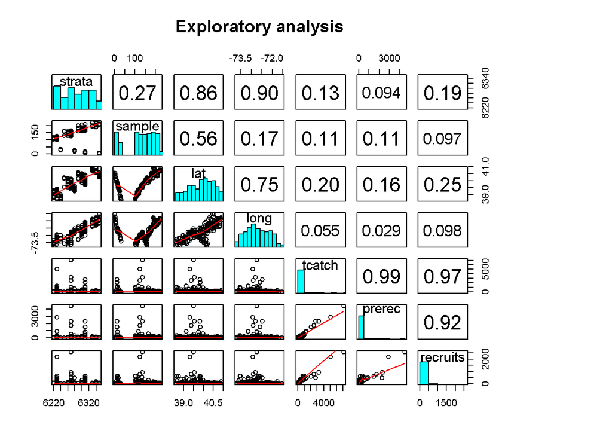

```r
panel.hist <- function(x){
  usr <- par("usr"); on.exit(par(usr))
  par(usr = c(usr[1:2], 0, 1.5) )
  h <- hist(x, plot = FALSE)
  breaks <- h$breaks; nB <- length(breaks)
  y <- h$counts; y <- y/max(y)
  rect(breaks[-nB], 0, breaks[-1], y, col=5)
}

panel.cor <- function(x, y, digits=2, prefix="", cex.cor){
  usr <- par("usr"); on.exit(par(usr))
  par(usr = c(0, 1, 0, 1))
  r <- abs(cor(x, y))
  txt <- format(c(r, 0.123456789), digits=digits)[1]
  txt <- paste(prefix, txt, sep="")
  if(missing(cex.cor)) cex <- 0.8/strwidth(txt)
  text(0.5, 0.5, txt, cex = cex )
}
pairs(myscallops,main = "Exploratory analysis", diag.panel=panel.hist, lower.panel=panel.smooth,oma=c(4,4,6,12), upper.panel=panel.cor)
```

#### Trasformazioni di variabili

Nell’ambito della trasformazione di variabili le medologie sono tante e per queste si lascia all’articolo dedicato al “preprocessing”. In questa sezione si mostra solamente la trasformazione in assoluto più semplice ma anche quella piu utilizzata: la trasformazione logaritmica. La trasformazione logaritmica non è sempre necessaria. Va fatta solo se vi è presente una relazione (grosso modo) esponenzialmente decrescente tra il valore della variabile e la sua frequenza per rendere i dati più normali.

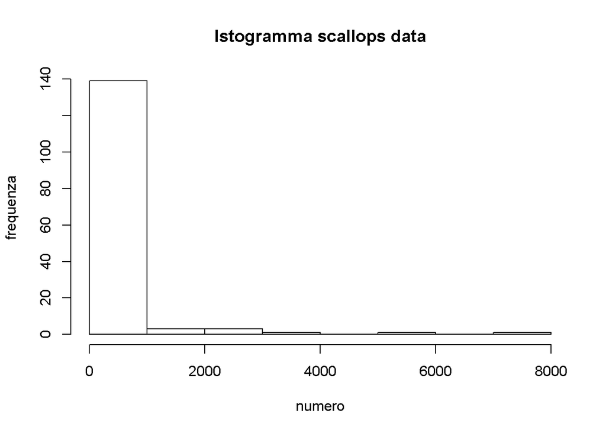

```r
hist(myscallops$tcatch,main="Istogramma scallops data",xlab="numero",ylab="frequenza")    # istogramma
```

```r
# trasformazione di variabili
myscallops[,"lgcatch"] <- log(myscallops$tcatch+1)  # aggiunge trasformata log di tcatch
summary(myscallops$lgcatch)
```

```
##    Min. 1st Qu.  Median    Mean 3rd Qu.    Max.
##   0.000   2.197   3.434   3.483   4.756   8.866
```

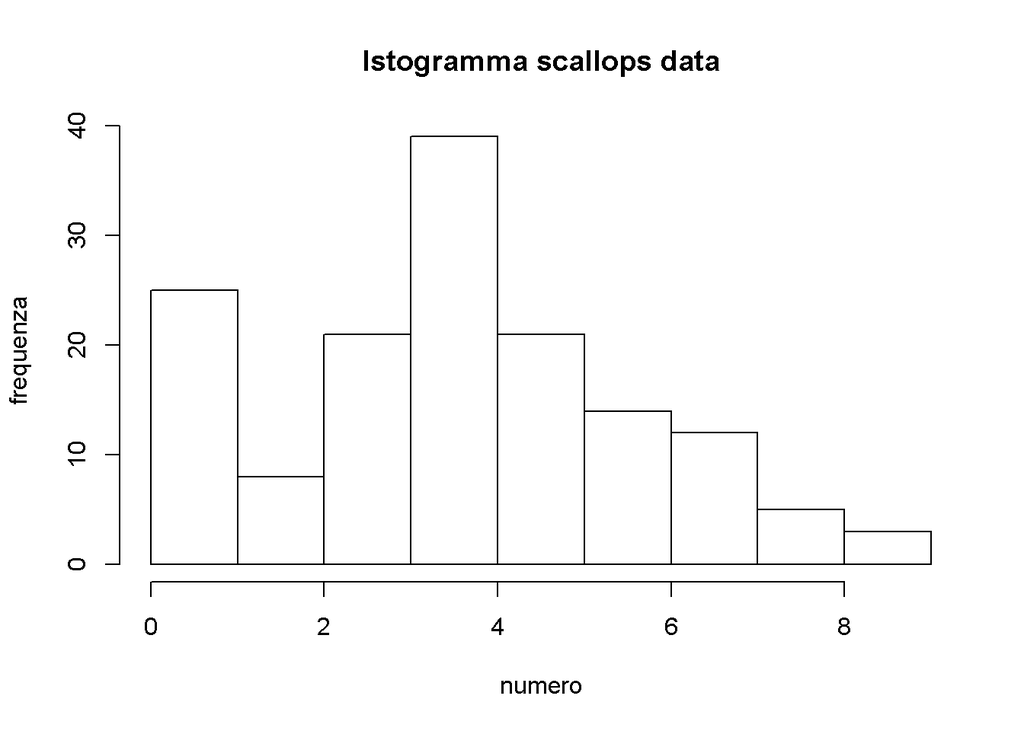

```r
hist(myscallops$lgcatch,main="Istogramma scallops data",xlab="numero",ylab="frequenza")    # istogramma
```

## ESDA (Exploratory Spatial Data Analysis)

#### Esplorazione spaziale dei dati

**Caricare le librerie**

```r
library(maps)   # carica libreria per mappe
library(spatstat)
```

**Visualizzazione dislocazione dei dati**

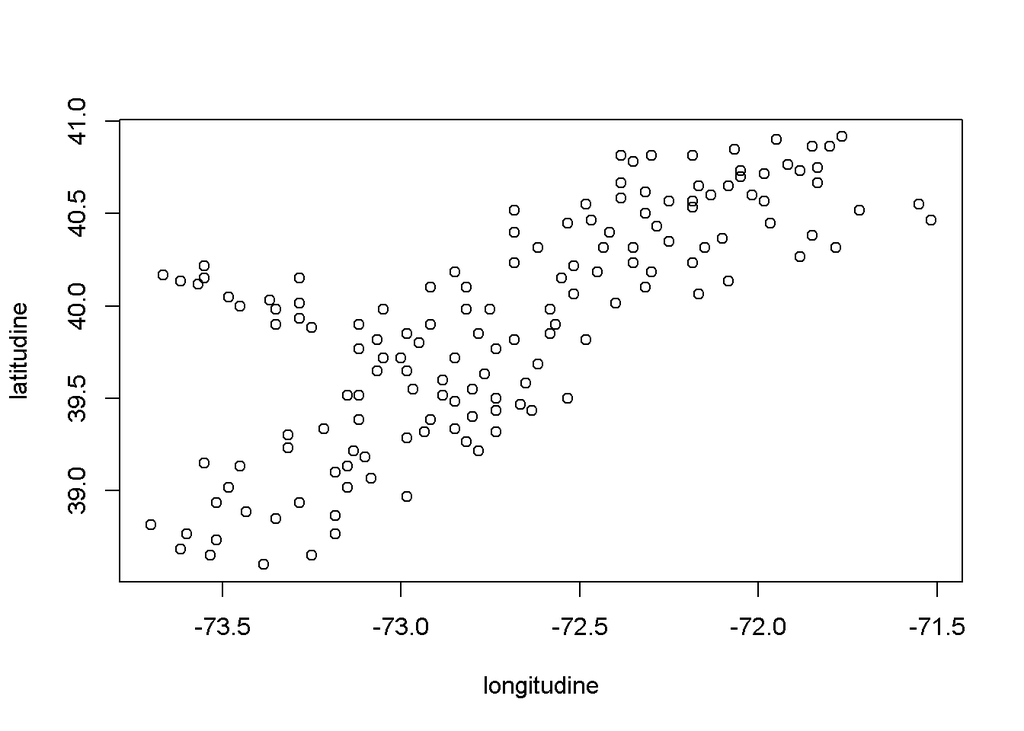

```r
# visualizzazione dislocazione dei dati
plot(myscallops$long, myscallops$lat,xlab="longitudine", ylab="latitudine") # mappa rilevazioni
```

**Caricare la mappa degli stati uniti**

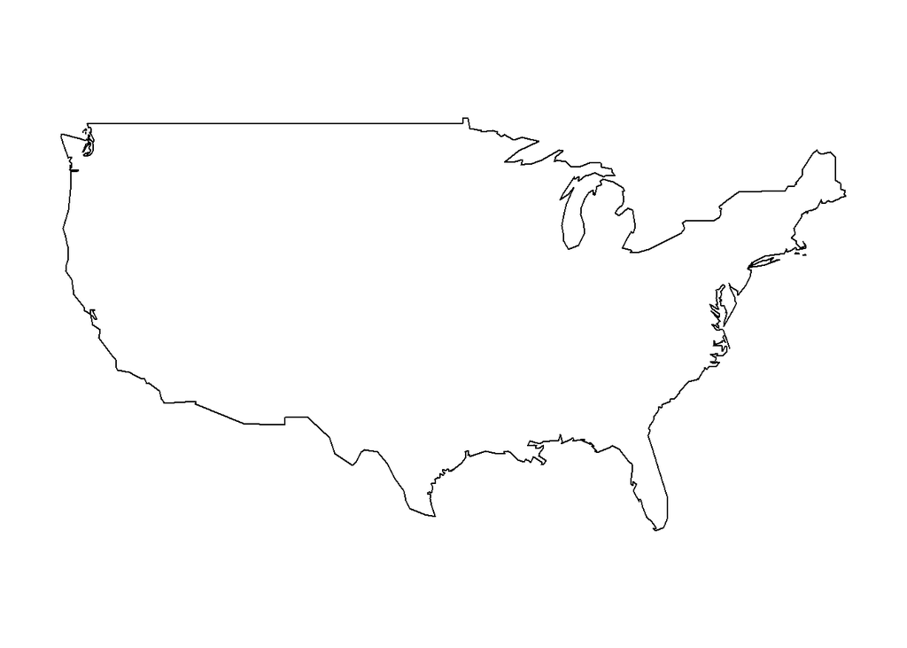

```r
# caricare la mappa degli stati uniti
map("usa")      # mappa degli USA- data set in R
```

**Zoommare sulla parte che ci interessa**

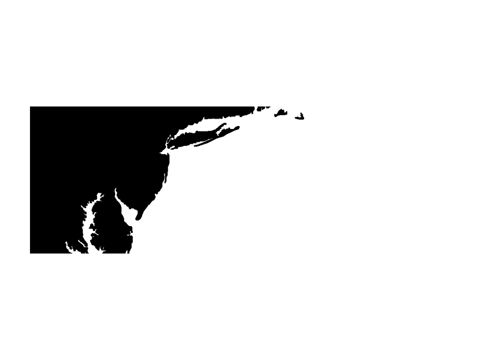

```r
#zoommare sulla parte che ci interessa
map("usa",fill=T, xlim=c(-78,-65), ylim=c(38.2,41.5))
```

**Aggiungere i punti**

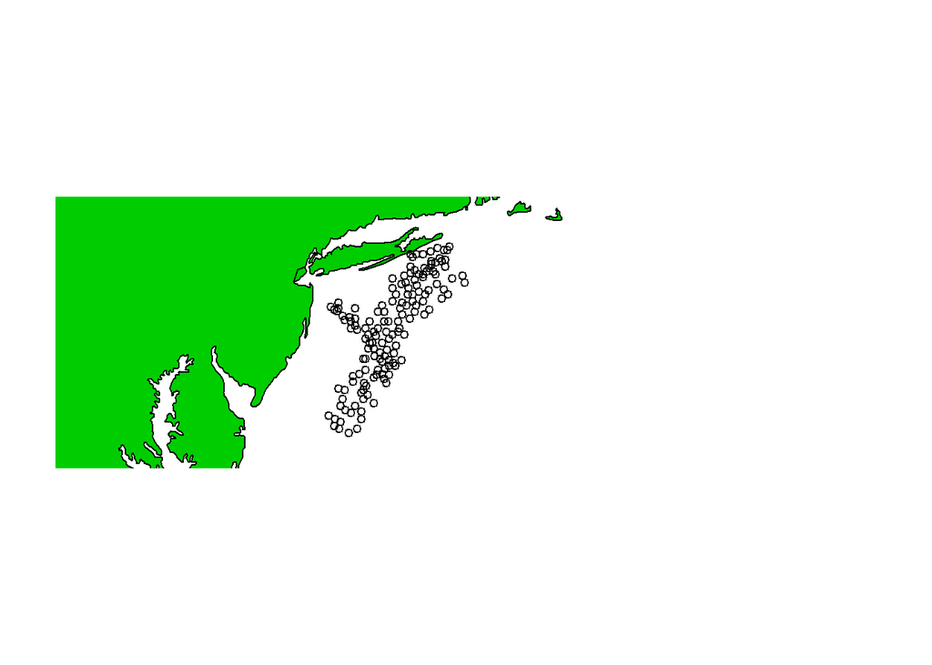

```r
# aggiungere i dati
map("usa",fill=T,col=3, xlim=c(-78,-65), ylim=c(38.2,41.5))   # seleziona area di interesse vedere il summary di scallops
points(myscallops$long, myscallops$lat,cex=0.8)   # aggiunge punti
```

**Operiamo una tassellatura per il test sui quadrat count ([spiegazione articolo link](https://giacomosaccaggi.github.io/articoli/PPSCSR.html))**

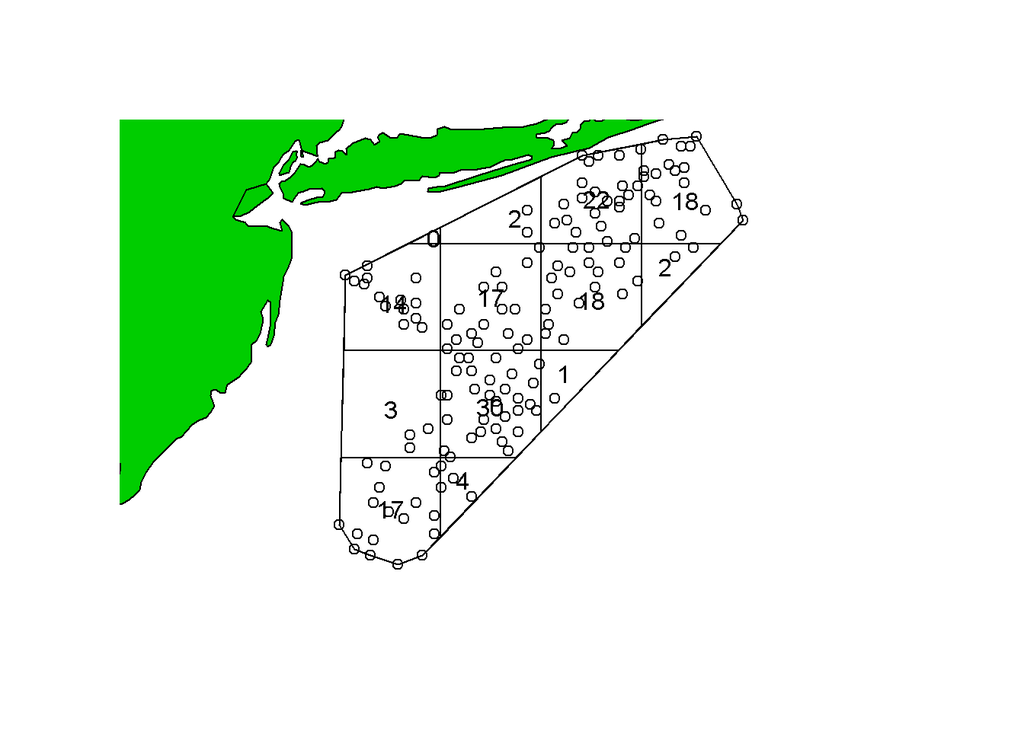

```r
w<-convexhull.xy(x=myscallops$long,y=myscallops$lat)  # involucro convesso
X<-ppp(myscallops$long,myscallops$lat,window=w) # oggetto point pattern
                                                   # Ipotizziamo che i siti siano un PP per poter usare la funzione quadratcount
plot(X,w,main="")
map("usa",fill=T,col=3, xlim=c(-78,-65), ylim=c(38.2,41.5),add=T)
celle=4
qx<-quadratcount(X,celle,celle)
plot(qx,add=T)
```

#### Calcolo statistiche locali

**Testare Eteroschedasticità spaziale**

```r
## calcolo statistiche locali
temp=data.frame(tcatch=myscallops$tcatch,
    lgcatch=myscallops$lgcatch,
    xclass=cut(myscallops$long,celle),
    yclass=cut(myscallops$lat,celle),
    conta=rep(1,length(myscallops$lgcatch))
    )
m<-data.frame(
    media=as.vector(tapply(temp$lgcatch, INDEX=list(temp$xclass,temp$yclass),FUN="mean")),
    varianza=as.vector(tapply(temp$lgcatch, INDEX=list(temp$xclass,temp$yclass),FUN="var")),
    frequenza=as.vector(tapply(temp$conta, INDEX=list(temp$xclass,temp$yclass),FUN="sum"))
    )
row.names(m)<-apply(expand.grid(paste("long:",levels(temp$xclass)),paste("lat:",levels(temp$yclass))), 1, paste, collapse="-")
m
```

```
##                                         media    varianza frequenza
## long: (-73.7,-73.2]-lat: (38.6,39.2] 3.886095  4.58809839        17
## long: (-73.2,-72.6]-lat: (38.6,39.2] 4.691872 10.30794243         4
## long: (-72.6,-72.1]-lat: (38.6,39.2]       NA          NA        NA
## long: (-72.1,-71.5]-lat: (38.6,39.2]       NA          NA        NA
## long: (-73.7,-73.2]-lat: (39.2,39.8] 3.467926  0.29295695         3
## long: (-73.2,-72.6]-lat: (39.2,39.8] 4.371972  6.45877485        30
## long: (-72.6,-72.1]-lat: (39.2,39.8] 0.000000          NA         1
## long: (-72.1,-71.5]-lat: (39.2,39.8]       NA          NA        NA
## long: (-73.7,-73.2]-lat: (39.8,40.3] 1.705076  2.35932631        14
## long: (-73.2,-72.6]-lat: (39.8,40.3] 3.652081  3.86154351        17
## long: (-72.6,-72.1]-lat: (39.8,40.3] 4.165445  4.56553525        18
## long: (-72.1,-71.5]-lat: (39.8,40.3] 0.000000  0.00000000         2
## long: (-73.7,-73.2]-lat: (40.3,40.9]       NA          NA        NA
## long: (-73.2,-72.6]-lat: (40.3,40.9] 3.074234  0.06761076         2
## long: (-72.6,-72.1]-lat: (40.3,40.9] 3.440629  1.78130086        22
## long: (-72.1,-71.5]-lat: (40.3,40.9] 2.569855  3.34954120        18
```

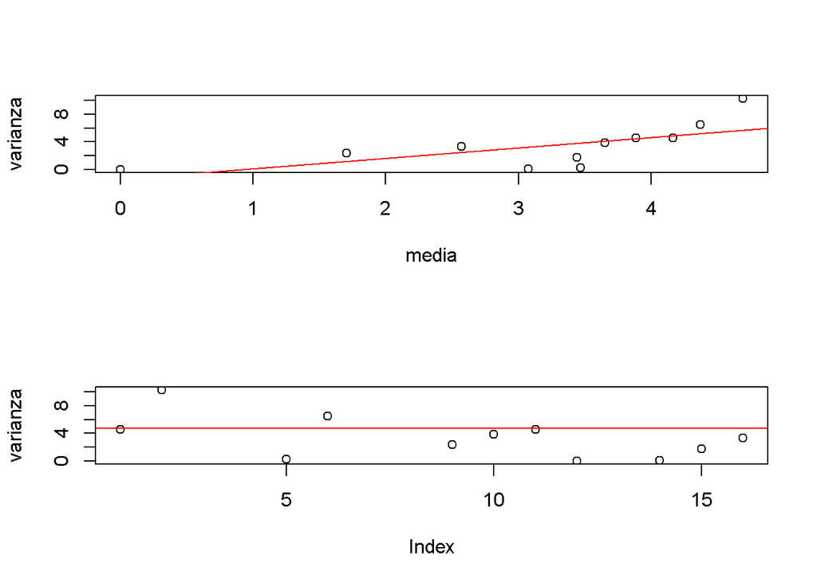

```r
par(mfrow=c(2,1))
plot(varianza~media,m,ylab="varianza",xlab="media");
abline(lm(varianza~media,m),col=2)
plot(m$varianza,ylab="varianza")
abline(h=var(temp$lgcatch),col=2)
```

### Esplorazione per la Stationarity di larga scala (in media)

**Relazione fra log-conteggi e locazioni**

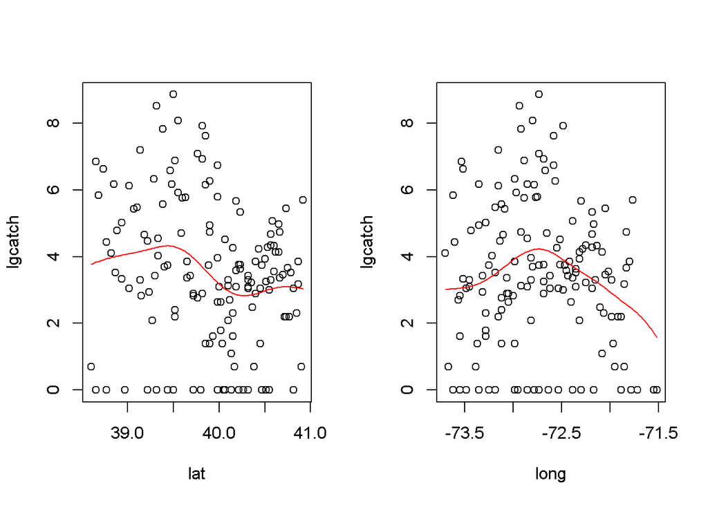

```r
#Le linee riportate sono ottenute tramite stimatori di regressione non parametrici (kernel)
par(mfrow=c(1,2))
with(myscallops, {
  plot(lat, lgcatch)
  lines(ksmooth(lat,  lgcatch, "normal", bandwidth=sd(myscallops$lat)),  col=2)
  plot(long, lgcatch)
  lines(ksmooth(long, lgcatch, "normal", bandwidth=sd(myscallops$long)), col=2)
})
```

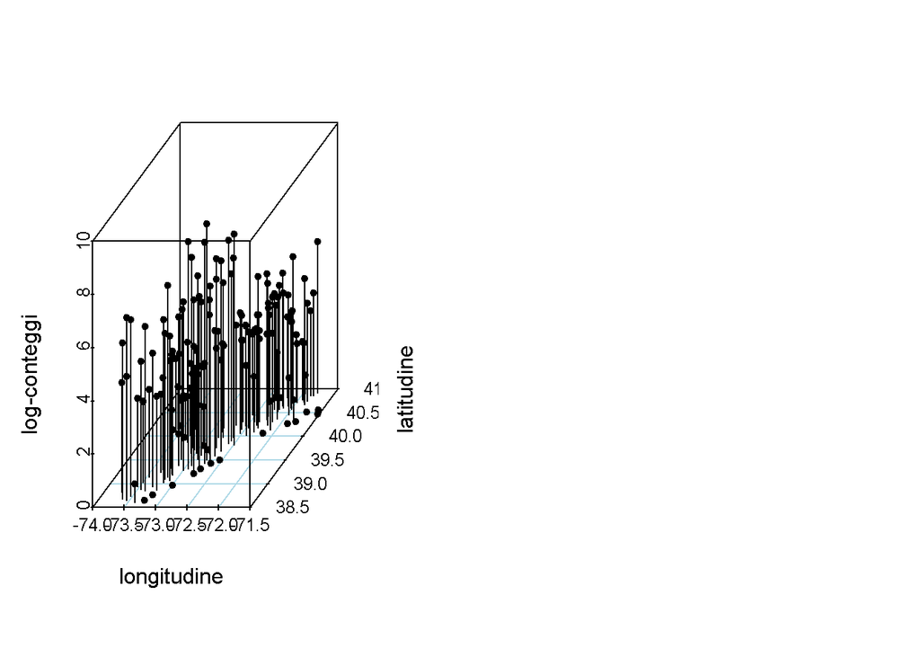

```r
# Analysis 3D
require(scatterplot3d)
s3d<-scatterplot3d(myscallops$long, myscallops$lat, myscallops$lgcatch,
                   xlab="longitudine",ylab="latitudine",zlab="log-conteggi",
                   col.grid="lightblue", pch=20,type="h")

# alternativamente si può usare:
library(rgl)
plot3d(myscallops$long, myscallops$lat, myscallops$lgcatch,
       xlab="longitudine",ylab="latitudine",zlab="log-conteggi",
       type="h",col.grid="lightblue", pch=20)
```

**Utilizziamo la libreria di geoR per trasformare il dataset in un oggetto GEODATA:**

```r
library(geoR)
obj <- cbind(myscallops$long,myscallops$lat,myscallops$lgcatch)
scallops.geo <- as.geodata(obj,coords.col=1:2,data.col=3)   # converte oggetto in classe geodata
class(scallops.geo); is.list(scallops.geo); length(scallops.geo); names(scallops.geo);
```

```
## [1] "geodata"
```

```
## [1] TRUE
```

```
## [1] 2
```

```
## $coords
## [1] "Coord1" "Coord2"
##
## $data
## [1] "data"
```

```r
head(scallops.geo$data); head(scallops.geo$coords)
```

```
## [1] 0.0000000 0.0000000 0.0000000 0.6931472 0.0000000 0.0000000
```

```
##         Coord1   Coord2
## [1,] -71.55000 40.55000
## [2,] -71.51667 40.46667
## [3,] -71.71667 40.51667
## [4,] -71.85000 40.38333
## [5,] -71.78333 40.31667
## [6,] -71.88333 40.26667
```

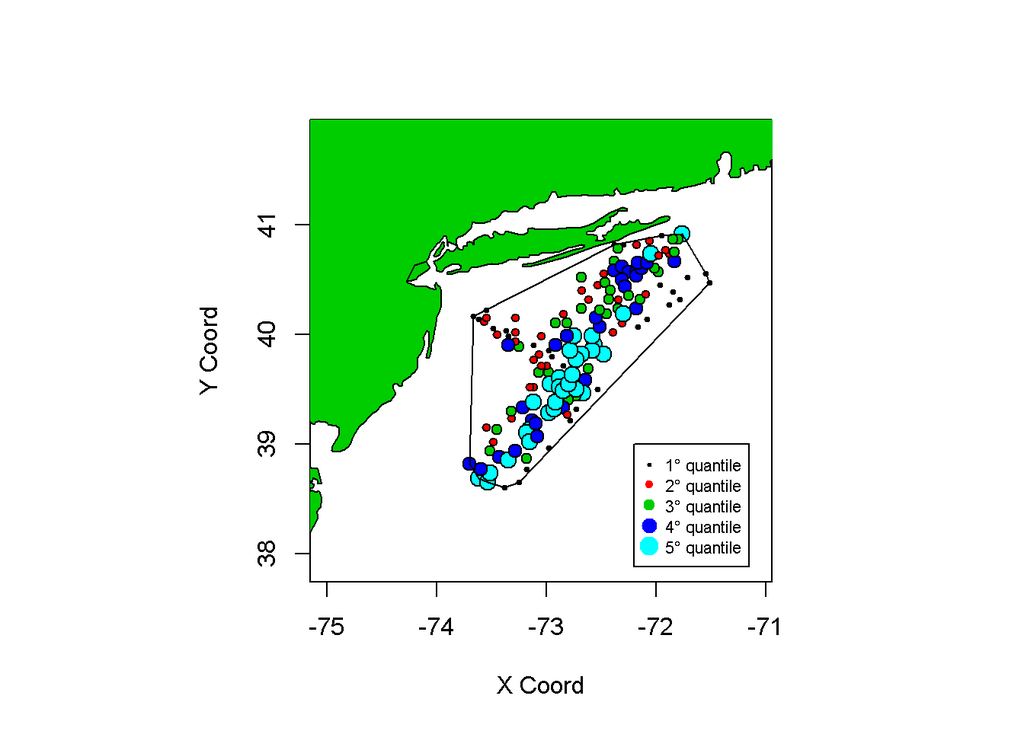

```r
points.geodata(scallops.geo,pt.divide="quintiles", col=1:5,xlim=c(-75,-71.1), ylim=c(38.2,41.5))
legend(-72.2, 39, pch=19, col=1:5, pt.cex=(1:5)/3,
    c("1° quantile","2° quantile","3° quantile","4° quantile","5° quantile"), cex = 0.7)
plot(w,add=T)
map("usa",fill=T,col=3,xlim=c(-75,-71.1), ylim=c(38.2,41.5),add=T)
```

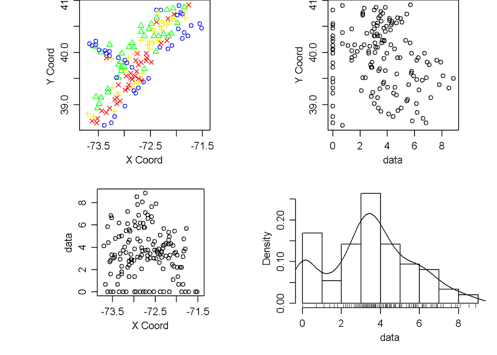

```r
# multiplot in geoR
plot.geodata(scallops.geo,scatter3d = FALSE)
```

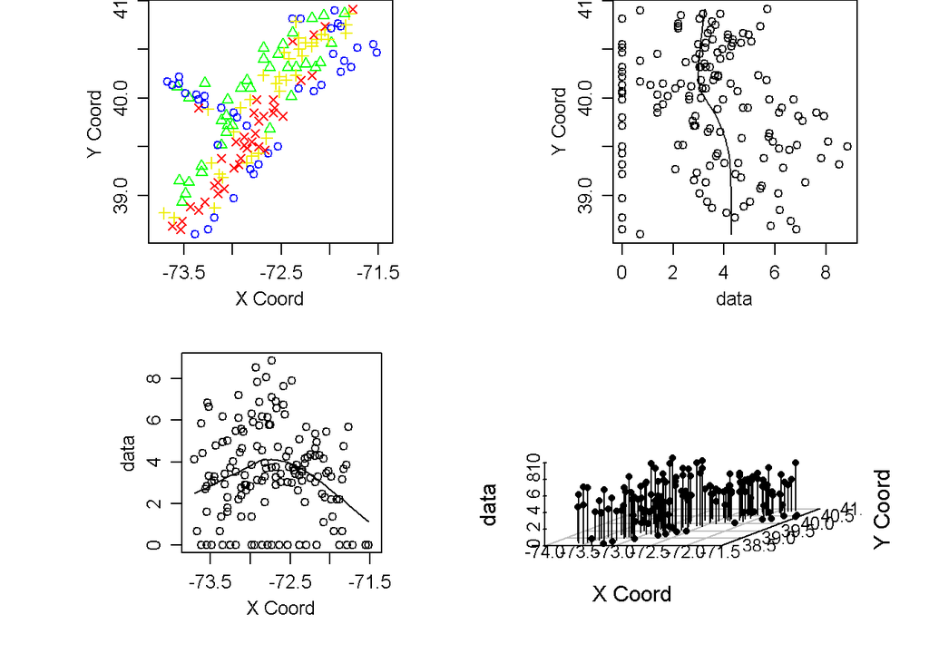

```r
plot.geodata(scallops.geo,scatter3d = TRUE, lowess=T)
```

```r
# creazione di griglia rettangolare su cui interpolare la superficie
lat.lim <- range(myscallops$lat)    # calcola il range
lon.lim <- range(myscallops$lon)
y <- seq(floor(lat.lim[1]),floor(lat.lim[2])+1,by=0.1)
x <- seq(floor(lon.lim[1]),floor(lon.lim[2])+1,by=0.1)
gr<-griglia<-expand.grid(x=x,y=y); dim(griglia)
```

```
## [1] 961   2
```

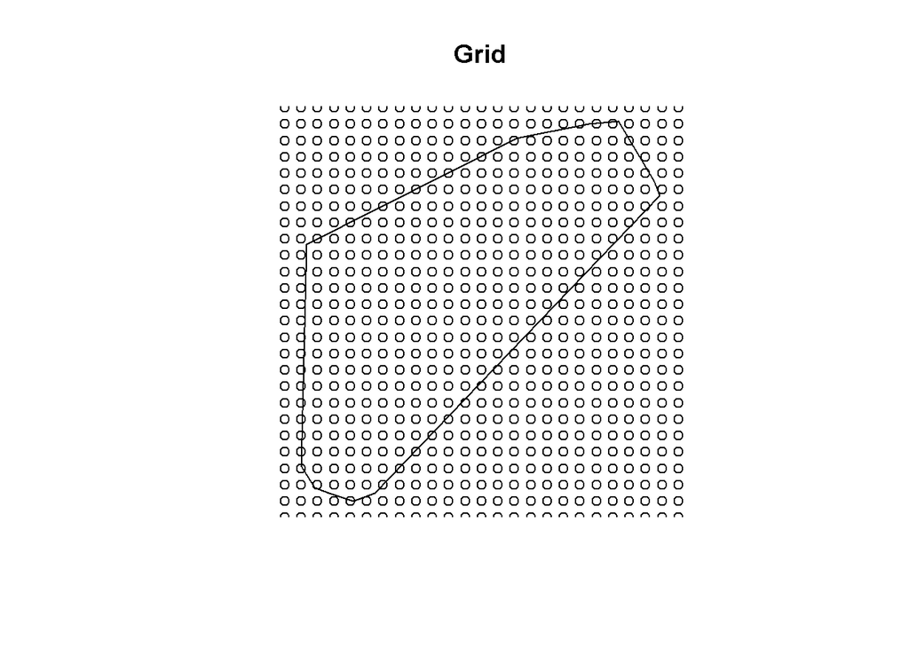

```r
plot(w,xlab="longitudine",ylab="latitudine", main = "Grid")
points(griglia)
```

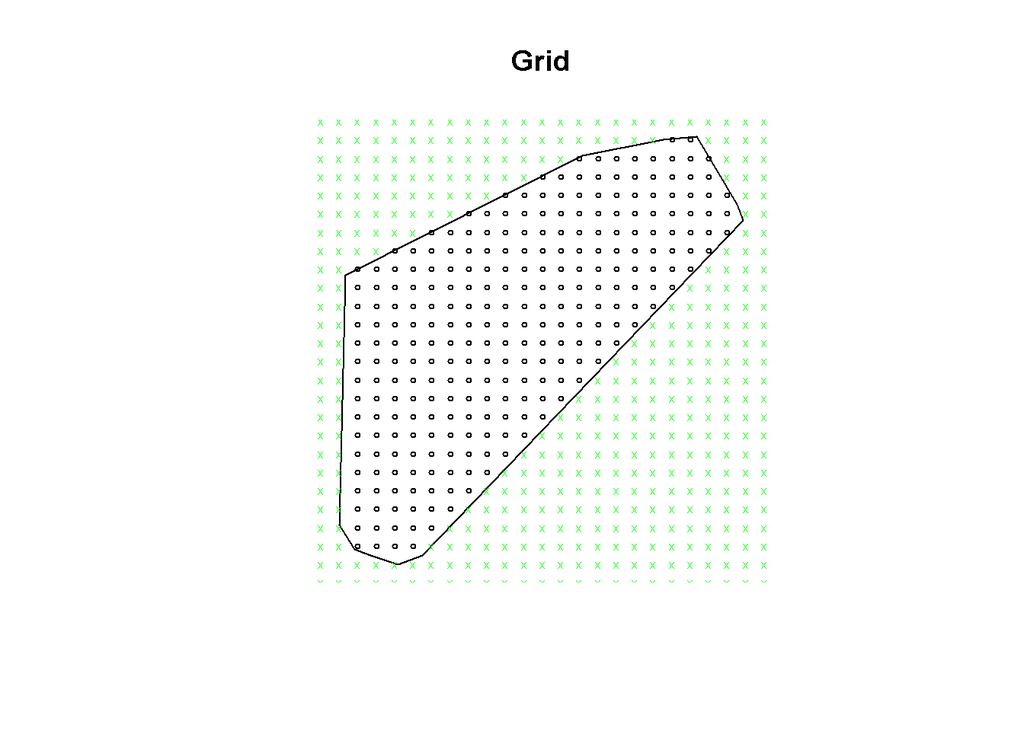

```r
# si identificano i punti griglia dentro involucro convesso
ok <- inside.owin(griglia$x, griglia$y, w) # nodi dentro involucro
plot(w, main = "Grid");
points(griglia$x[ok], griglia$y[ok],cex=0.5)
points(griglia$x[!ok], griglia$y[!ok], pch="x",cex=0.5,col="green")
```

```r
#


library(gstat)
```

```r
library(maptools)
locazioni=data.frame(lon=myscallops$lon,lat=myscallops$lat,lgcatch=myscallops$lgcatch)
coordinates(locazioni)=c("lon","lat")
coordinates(griglia) = ~x+y
idw.p=gstat::idw(formula=lgcatch ~ 1, locations=locazioni, newdata=griglia,
                 nmax = 15, idp = 2)
```

```
## [inverse distance weighted interpolation]
```

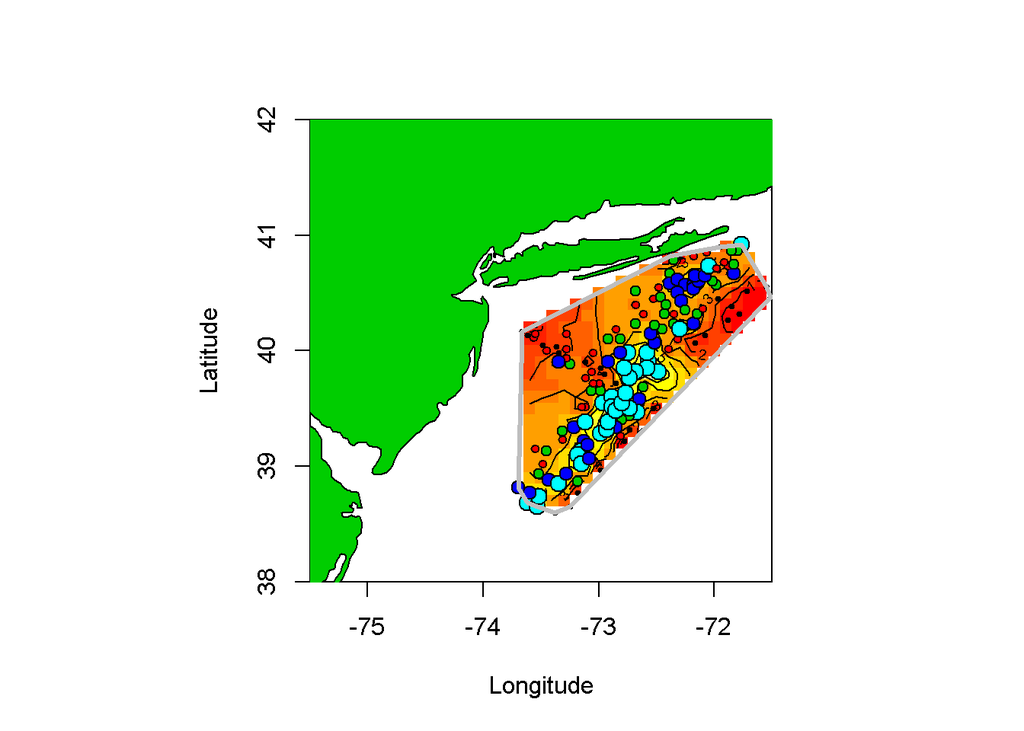

```r
idw.o=as.data.frame(idw.p)
names(idw.o)[1:3]<-c("long","lat","lgcatch")
idw.o[!ok,"lgcatch"] <- NA
surface<-matrix(idw.o$lgcatch,byrow=F,nrow=length(y))
int.scp <-list(x=x,y=y,z=surface)
image(int.scp, xlab="Longitude", ylab="Latitude",xlim=c(-75.5,-71.50), ylim=c(38,42))
contour(int.scp, add=T)
points.geodata(scallops.geo,pt.divide="quintiles", col=1:5,add=T)
map("usa", add=T, xlim=c(-74,-71), ylim=c(38.2,41.5),fill=T,col=3,
    xlab="longitudine",ylab="latitudine")
plot(w,border="gray",add=T,lwd=3)
map("usa", add=T, xlim=c(-74,-71), ylim=c(38.2,41.5),fill=T,col=3,
    xlab="longitudine",ylab="latitudine")
```

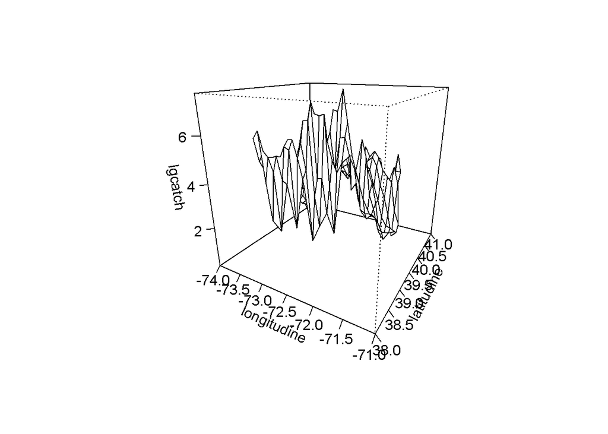

```r
persp(int.scp,xlab="longitudine",ylab="latitudine",zlab="lgcatch",
      expand=1,theta=30,phi=20,ticktype="detailed" ) # per modificare angolazione cambiare i parametri theta e phi
```